# QSBS Basic statistics example exam — model answers

# Marking notes

The points per sub-question are given in the exam (total 20). For the R sub-questions, roughly half of the points are for correct code and numbers and half for the interpretation. Alternative correct routes (e.g. `lm()` instead of `glm(..., family = gaussian)`, `quasipoisson` instead of `glm.nb()` in Question 5 with a matching interpretation) receive full marks.

```r
library(qsbsdata)
library(MASS)
library(car)
```

# Question 1 — Descriptive statistics

## a (1 pt)

```r
x <- Swallowtail$Forewing_area
c(n = length(x), mean = mean(x), median = median(x), sd = sd(x), IQR = IQR(x),
  skewness = mean((x - mean(x))^3) / sd(x)^3)
```

```
##           n        mean      median          sd         IQR    skewness
## 194.0000000   5.2631753   5.1940000   0.7599924   0.9542500   0.2242384
```

Mean 5.26 cm², median 5.19 cm², SD 0.76 cm², IQR 0.95 cm², skewness 0.22.

## b (1 pt)

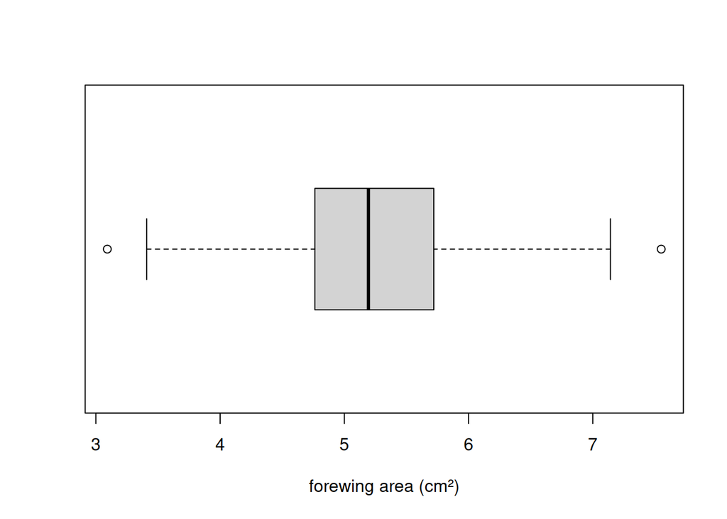

```r
boxplot(x, horizontal = TRUE, las = 1, xlab = "forewing area (cm²)")
```

```r
boxplot.stats(x)$stats
```

```
## [1] 3.409 4.763 5.194 5.720 7.142
```

```r
boxplot.stats(x)$out
```

```
## [1] 3.092 7.551
```

Mean and median are almost equal, the skewness is small and positive, and the box is roughly symmetric around the median: the distribution is close to symmetric with a slightly longer right tail. Two values are flagged as boxplot outliers, the smallest (3.09 cm²) and the largest (7.55 cm²) butterfly. They are only just beyond the whiskers, they lie on opposite sides, and both are biologically plausible sizes; they are no reason for concern and should not be removed.

# Question 2 — Association between categorical variables

## a (1 pt)

```r
tab <- table(Swallowtail$Species, Swallowtail$Sex)
tab
```

```
##
##                               female male
##   Papilio machaon britannicus     55   83
##   Papilio machaon gorganus        20   36
```

```r
round(prop.table(tab, margin = 1), 3)
```

```
##
##                               female  male
##   Papilio machaon britannicus  0.399 0.601
##   Papilio machaon gorganus     0.357 0.643
```

Within *P. m. britannicus* 40 % of the butterflies are female (55 of 138), within *P. m. gorganus* 36 % (20 of 56).

## b (2 pt)

```r
ch <- chisq.test(tab)
ch
```

```
##
##  Pearson's Chi-squared test with Yates' continuity correction
##
## data:  tab
## X-squared = 0.13987, df = 1, p-value = 0.7084
```

```r
round(ch$expected, 1)
```

```
##
##                               female male
##   Papilio machaon britannicus   53.4 84.6
##   Papilio machaon gorganus      21.6 34.4
```

The expected counts under independence (53.4 / 84.6 and 21.6 / 34.4) are very close to the observed counts. The chi-square test (with continuity correction) gives $\chi^2 = 0.14$ on 1 df, $p = 0.71$ (without correction $p = 0.59$). Conclusion: there is no evidence that the sex ratio differs between the two subspecies; the small difference in the proportion of females is well within what chance would produce.

# Question 3 — Probability distributions

## a (1 pt)

```r
mu <- 5.26; sigma <- 0.73
c(p_above_6.5   = pnorm(6.5, mu, sigma, lower.tail = FALSE),
  p_4.5_to_6.0  = pnorm(6.0, mu, sigma) - pnorm(4.5, mu, sigma),
  q_95          = qnorm(0.95, mu, sigma))
```

```
##  p_above_6.5 p_4.5_to_6.0         q_95
##   0.04469445   0.69572119   6.46074315
```

1. $P(X > 6.5) = 0.045$; (ii) $P(4.5 < X < 6.0) = 0.70$; (iii) the 95 % quantile is 6.46 cm²: only 5 % of butterflies are larger than that.

## b (1 pt)

```r
c(observed_above_6.5 = mean(x > 6.5),
  observed_q95       = quantile(x, 0.95))
```

```
## observed_above_6.5   observed_q95.95%
##         0.05670103         6.52485000
```

Observed: 5.7 % of the butterflies (11 of 194) exceed 6.5 cm², against 4.5 % predicted, and the observed 95 % quantile is 6.52 cm² against 6.46 cm² predicted. The agreement is good; the slightly heavier observed upper tail is consistent with the small positive skewness found in Question 1. The normal distribution is a reasonable description of forewing area.

# Question 4 — GLM interpretation

## a (1 pt)

The response is binary (0/1), so the appropriate model is a binomial GLM with the logit link (logistic regression).

```r
fb <- glm(RODENTSP ~ PERSHRUB, family = binomial, data = bolger)
summary(fb)$coefficients
```

```
##                Estimate Std. Error   z value    Pr(>|z|)
## (Intercept) -3.90342422  1.5577497 -2.505810 0.012217139
## PERSHRUB     0.07662335  0.0287754  2.662808 0.007749163
```

Fitted model: $\mathrm{logit}(p) = \ln\frac{p}{1-p} = -3.90 + 0.0766 \cdot \mathrm{PERSHRUB}$, with $\mathrm{RODENTSP} \sim \mathrm{Bern}(p)$; link function: logit. The slope is significantly positive ($z = 2.66$, $p = 0.008$).

## b (1 pt)

```r
predict(fb, newdata = data.frame(PERSHRUB = c(20, 50, 80)), type = "response")
```

```
##          1          2          3
## 0.08541433 0.48194368 0.90259917
```

```r
exp(10 * coef(fb)["PERSHRUB"])
```

```
## PERSHRUB
## 2.151647
```

Predicted probabilities of rodent presence: 0.09 at 20 % shrub cover, 0.48 at 50 % and 0.90 at 80 %. The coefficient is the change in log-odds per 1 % cover, so per 10 % cover the odds are multiplied by $e^{10 \times 0.0766} = 2.15$: every additional 10 % of shrub cover roughly doubles the odds of native rodents being present.

## c (2 pt)

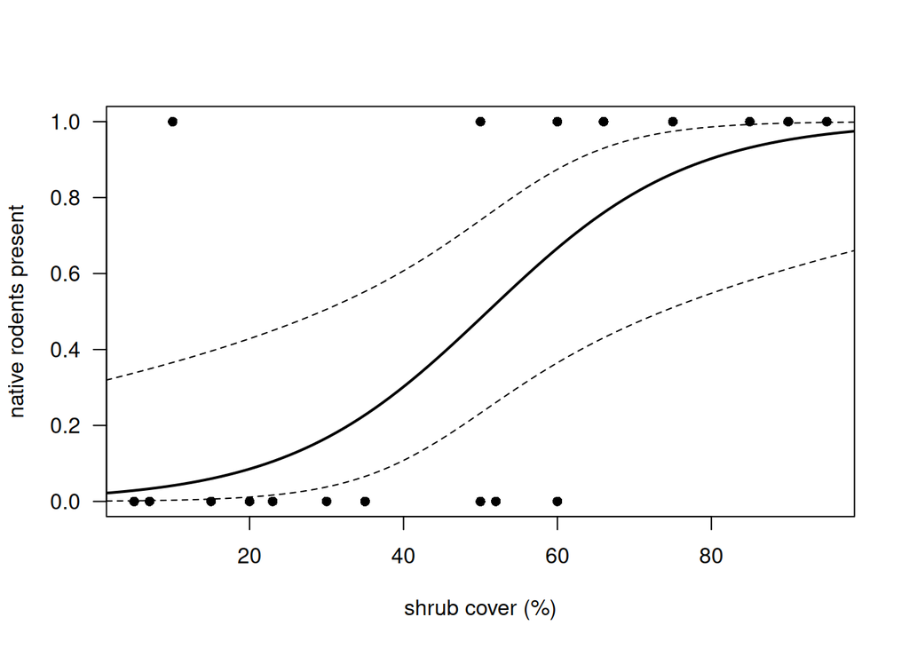

Presence of native rodents against shrub cover, with the fitted logistic curve and 95 % confidence band.

```r
xnew <- seq(0, 100, length = 100)
pr <- predict(fb, newdata = data.frame(PERSHRUB = xnew), se.fit = TRUE)     # link scale
plot(RODENTSP ~ PERSHRUB, data = bolger, pch = 16, las = 1,
     xlab = "shrub cover (%)", ylab = "native rodents present")
matlines(xnew, plogis(cbind(pr$fit, pr$fit - 2 * pr$se.fit, pr$fit + 2 * pr$se.fit)),
         lty = c(1, 2, 2), col = "black", lwd = c(2, 1, 1))
```

Key points: the standard errors are obtained on the link scale (`se.fit = TRUE`), the band is constructed as fit ± 2 SE on that scale and only then back-transformed with `plogis()`, so the band stays within [0, 1] and is asymmetric.

# Question 5 — GLM comparison

## a (1 pt)

```r
birds$logarea <- log(birds$area)
fp <- glm(S ~ logarea, family = poisson, data = birds)
c(deviance_ratio = deviance(fp) / df.residual(fp))
```

```
## deviance_ratio
##        1.52515
```

```r
fn <- glm.nb(S ~ logarea, data = birds)
fn$theta
```

```
## [1] 47.82332
```

The residual deviance / df ratio of the Poisson model is 1.53, well above 1: the counts are overdispersed. A negative binomial GLM (`glm.nb`, $\hat\theta = 48$) is the appropriate refit; a quasi-Poisson model would be an acceptable alternative.

## b (1 pt)

```r
rbind(poisson = summary(fp)$coefficients["logarea", 1:2],
      negbin  = summary(fn)$coefficients["logarea", 1:2])
```

```
##          Estimate Std. Error
## poisson 0.2378341 0.01331710
## negbin  0.2463928 0.01686803
```

The slope estimate hardly changes (0.238 → 0.246 per unit of log area), but its standard error increases from 0.013 to 0.017. The Poisson model overstated the precision of the slope: confidence intervals should be about 25 % wider and p-values larger than the Poisson output suggests. Here the effect of area is so strong ($z = 14.6$ even in the negative binomial model) that the conclusion — richness increases with patch area — is unaffected, but the reported uncertainty should come from the negative binomial model.

# Question 6 — Multiple regression interpretation

```
##             Estimate Std. Error t value Pr(>|t|)
## (Intercept)  11.9913     1.0985 10.9158   0.0000
## age           0.0368     0.0077  4.7752   0.0000
## AspectNorth  -0.5031     1.0939 -0.4600   0.6462
## AspectSouth  -2.2930     1.0002 -2.2925   0.0232
## AspectWest   -2.3536     1.1066 -2.1268   0.0350
```

```
## Analysis of Variance Table
##
## Model 1: dbh ~ age + Aspect
## Model 2: dbh ~ age * Aspect
##   Res.Df    RSS Df Sum of Sq      F Pr(>F)
## 1    155 2900.1
## 2    152 2861.2  3    38.929 0.6894 0.5599
```

```
##        df      AIC
## fp_add  6 929.6324
## fp_int  9 933.4701
```

## a (1 pt)

The reference level is **East** (alphabetically first; it does not appear among the coefficients). In Model A the `age` coefficient 0.0368 is the increase in maximum stem diameter per year of lifespan, the same for all aspects: a tree that lives 100 years longer reaches a diameter that is on average 3.7 cm larger.

## b (1 pt)

A 200-year-old tree on a North-facing site: $11.99 + 0.0368 \times 200 - 0.50 = 18.85$ cm.

## d (1 pt)

No. The three interaction terms together reduce the residual sum of squares by only 39 ($F = 0.69$ on 3 and 152 df, $p = 0.56$), and the AIC increases from 929.6 to 933.5 when they are added. Report Model A: diameter increases with lifespan at the same rate on all aspects, and at a given age trees on South- and West-facing sites are about 2.3 cm thinner than on East-facing sites ($p = 0.02$ and $0.04$), whereas North-facing sites do not differ from East-facing ones ($p = 0.65$).

# Question 7 — Regression diagnostics

## c (1 pt)

Any one of the following (with what to look for):

- a plot of the standardised residuals against the *predictor* (nitrogen dose), or a boxplot of the residuals per dose group, to check for constant variance — the desired pattern is an equal spread at every dose; here the spread looks larger at nitrogen = 0;
- a normal QQ-plot of the standardised residuals — the desired pattern is points along the straight line, which justifies the gaussian assumption behind the F-test and the confidence band;
- a comparison with an alternative functional form, e.g. a saturating (Michaelis–Menten or log) model, which does not predict a decline at high doses — the desired outcome is that the quadratic is not clearly beaten (AIC) and that the extrapolation beyond 200 lb/acre is not driving the fit;
- a refit without the three influential plots — the desired outcome is that the coefficients and the conclusions do not change substantially.